# Inferential Statistics Project

Aviv Gelfand and Maor Moshe - 03/12/2022

#### Recall of our previous project

Recall that in the previews project we used WHO table of Average BMI and life expectancy for 177 countries in the world. [Source](https://www.kaggle.com/datasets/kumarajarshi/life-expectancy-who?resource=download).

**Predicted / dependent variable Y**: Life expectancy - refers to average number of years a person can expect to live in a country.

**Undependable variable X**: BMI - Body Mass Index units. A calculation using a person’s height and weight.

**We hypothesized** that BMI is an explanatory variable for a person’s life expectancy.

### Question 1) Point Estimators

##### **1. a)** Estimating Expectency and Variance Y

Let’s assume that the predicted value, the average life expectancy in the country, is normally distributed.

We could define an estimator for the expectancy according to the method of MLE or the moment’s method (the same, a result in a normal distribution).

$\hat{\mu_y} := \overline{Y} = \frac{1}{n} \sum_{i = 1}^{n}y_i$ = 71.82

$\hat{\sigma^2_y} := \overline{Y^2} - \overline{Y}^2= \frac{1}{n} \sum_{i = 1}^{n}(y_i-\overline{Y})^2 =$ 64.89

In addition, we learned in class about a conventional unbiased estimator for the variance of a normal distribution:

$\hat{\sigma^2_y} := S^2_n :=\frac{1}{n-1}\sum_{i = 1}^{n}(y_i-\overline{Y})^2 =$ 65.26

We will proceed with the conventional estimator $S^2_n$ in the following questions.

##### **1. b)** Estimating Expectency and Variance of X using Gamma

We denote the independent variable, BMI as $X$, then:

Let $m=min(X)$ and Let $W:=X-m$ and assume $W \sim Gamma(\alpha, \lambda)$

Then, by the formulas we prooved in class, the point estimator of $\alpha$ would be: $\hat{\alpha}=\frac{\overline{W}^2}{\overline{W}^2-\overline{W^2}}$ = 5.19

And the point estimator of $\lambda$ would be: $\hat{\lambda}=\frac{\overline{W}}{\overline{W}^2-\overline{W^2}}$ = 1

Thus, $W:= X-m \sim Gamma(\alpha =$ 5.19 $, \lambda =$ 1 $)$

##### **1. c-d)** Theoretical and Empirical Quantiles [0.1,0.5,0.75,0.9] of X,Y and W:

|  | 0.1 | 0.5 | 0.75 | 0.9 |
| --- | --- | --- | --- | --- |
| Y_Theoretical | 61.471228 | 71.823729 | 77.272324 | 82.176229 |
| Y_Empirical | 59.900000 | 74.000000 | 77.000000 | 81.840000 |
| X_Theoretical | 22.967133 | 25.260743 | 26.893732 | 28.639136 |
| X_Empirical | 22.500000 | 26.200000 | 27.200000 | 27.900000 |
| W_Theoretical | 2.567133 | 4.860743 | 6.493732 | 8.239136 |
| W_Empirical | 2.100000 | 5.800000 | 6.800000 | 7.500000 |

We can see a similarity between the theoretical and the empirical parameters.

##### **1. e) Bonus:** Plotting the Theoretical VS Empirical precentiles

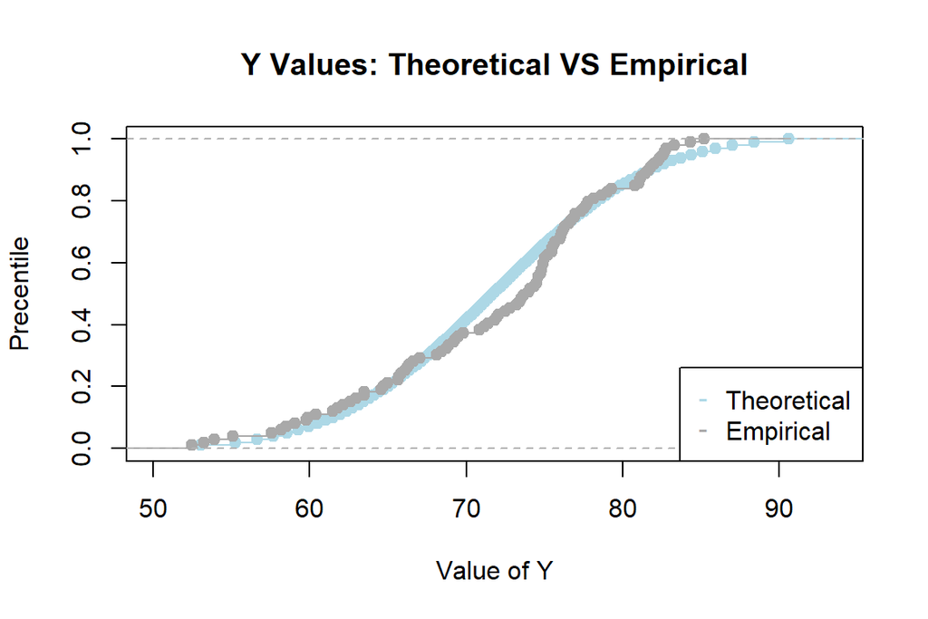

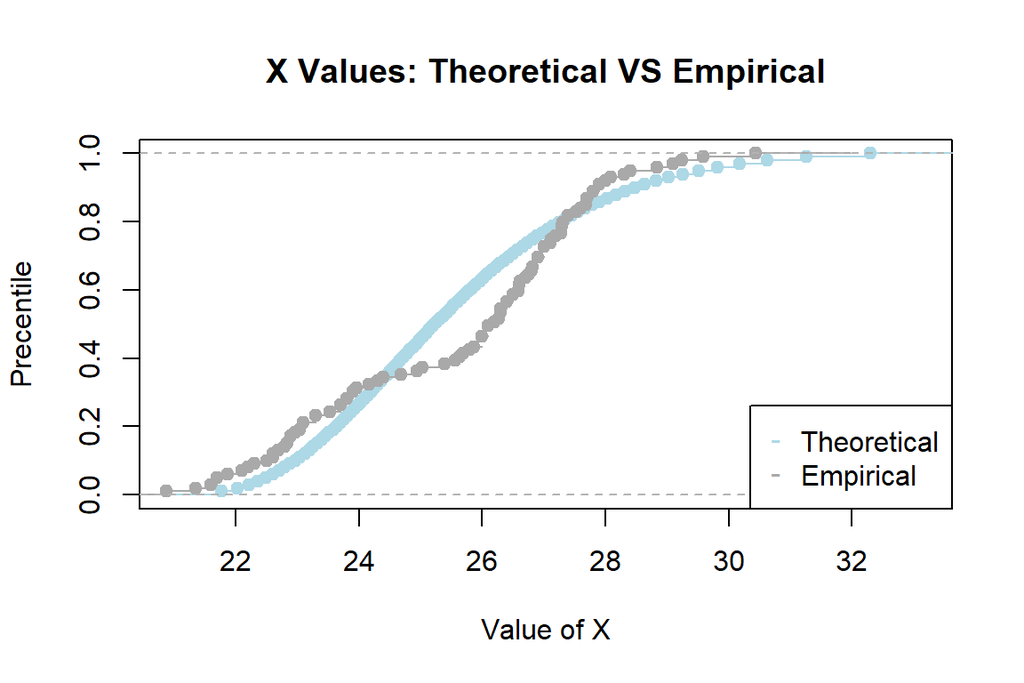

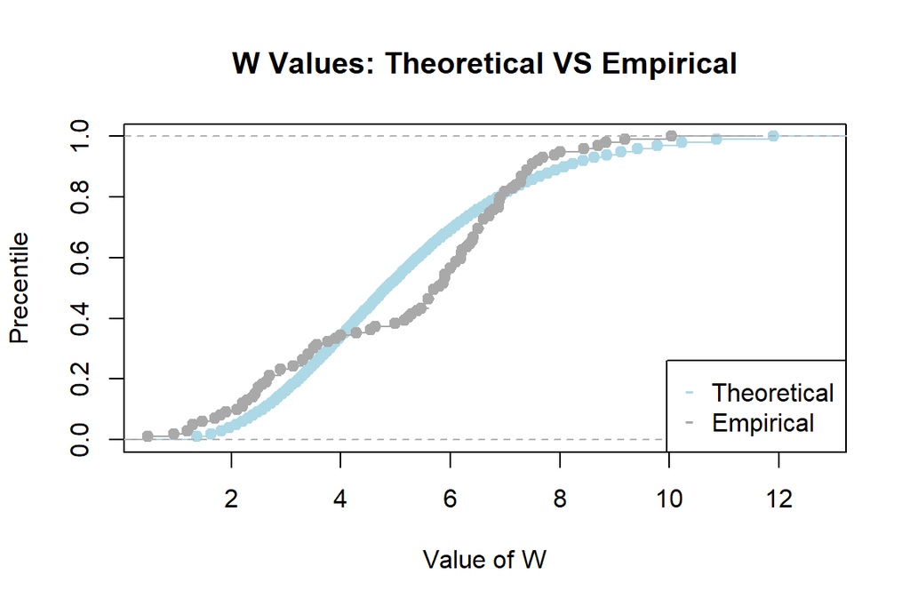

## Question 2 - Confidence Intervals

#### **CI of E[Y]** where confidence level is 97%

We don’t know What $\sigma_Y$ is. Hence, we calculate the confidence interval of an expected life expectancy in a country (our Y) as follows:

$CI = [\overline{Y_n} \pm t_{n-1,1-\frac{a}{2}} \ \frac{S_n}{\sqrt[]{n}}] = [71.82\pm t_{n=177, \ df=0.985} \ \frac{8.07}{ \sqrt[]{177} }] = [70.49, \ 73.15]$

## Question 3 - Hypotheses Testing

We want to examine if there is a correlation between the Average BMI ($X$) and Life Expectancy ($Y$) in a country.

We divide all of our (X,Y) to: $U = \{(X_i,Y_i)| X_i \ge med(X_i)\}$ and: $L = \{(X_i,Y_i)| X_i < med(X_i) \}$.

$U$ denotes the **higher BMI world** $:=$ countries where the average person has a higher BMI than the median BMI in the world.

$L$ denotes the **lower BMI world** $:=$ countries where the average person has a lower BMI than the median BMI in the world.

#### **3. a)** Verbal formulation of the research hypotheses

Our null hypothesis ($H_0$) assumes no correlation between Life expectancy ($Y$) and Average BMI ($X$). In other words, $H_0$ assumes both of our examined groups are identical, such that the difference of their means is equal to zero.

**Our alternative hypothesis** ($H_1$) is that the **higher BMI world** would have a higher Life Expectancy then the *lower BMI world* (higher BMI where countries are richer).

#### **3. b)** Statistical formulation of our hypotheses

Let us denote $D= Y_U-Y_L$

Then:

$H_1: \mu_{_D} > 0$

#### **3. c)** Building a statistical test.

Our test-statistic is $\overline D$. We don’t know it’s real variance then $D \sim t_{88}$ under $H_0$.

Then: $P_{val}:= p_{_{H_0}}(Reject \ H_0) \underset{\overline D > 0}= 1-pt_{88}(\cfrac{\overline{D}\ -\ 0}{\sqrt{S_n^2/n}})=$ 1.8496316^{-13}

This is a very small p-value, which suggests that the difference in means between the two groups is statistically significant for every $\alpha$. In other words, the data provides strong evidence against $H_0$.

#### **3. d)** Applying our statistical test

Based on the p-value, we can conclude that the mean life expectancy of the High BMI” group group is significantly greater then the mean life expectancy of the “Low BMI” group.

**The End**